# Midterm Exam - MLC Fall 2024

Total points for the midterm exam: 15. More detailed instructions are in the PDF file in Brightspace.

Please note: Copying and pasting other people's work is absolutely prohibited. Any such cases will be reported to CUSP's education team and severely punished. Discussion is encouraged, and feel free to exchange ideas with your classmates, but please write your own code and do your own work.

## Part A - Ensemble Methods (30% + 10% with optional extra)

### Task 1: Create and Visualize Decision Trees (extra 10%)

##### This task 1 (decision trees) is optional, and you can get an extra 10% if you decide to do this task.

```python
import pandas as pd
from sklearn.model_selection import train_test_split
from sklearn.tree import DecisionTreeClassifier
from sklearn.metrics import accuracy_score
import matplotlib.pyplot as plt
from sklearn.tree import plot_tree
```

The provided **Telecom dataset** encompasses diverse parameters associated with telecom customers and aims to predict whether a customer is likely to stay (Contract Closure = 0) or leave (Contract Closure = 1) the telecom service provider. Each row represents a customer, and the columns include various features such state, total miutes of usage internet service, and more. The target variable, "Contract Closure," serves as the binary indicator for customer churn prediction, with 0 indicating the customer stays and 1 indicating the customer leaves the telecom service.

```python
# Load the dataset

data = pd.read_csv("telecom_dataset.csv")
data=data.dropna()
```

```python
data
```

|  | State_FIPS | Account length | Area code | Number vmail messages | Total day minutes | Total day calls | Total day charge | Total eve minutes | Total eve calls | Total eve charge | Total night minutes | Total night calls | Total night charge | Total intl minutes | Total intl calls | Total intl charge | Customer service calls | Contract Closure |
| --- | --- | --- | --- | --- | --- | --- | --- | --- | --- | --- | --- | --- | --- | --- | --- | --- | --- | --- |
| 0 | 1 | 118 | 510 | 0 | 223.4 | 98 | 37.98 | 220.6 | 101 | 18.75 | 203.9 | 118 | 9.18 | 6.3 | 6 | 1.70 | 0 | 0 |
| 1 | 1 | 98 | 408 | 0 | 161.0 | 117 | 27.37 | 190.9 | 113 | 16.23 | 227.7 | 113 | 10.25 | 12.1 | 4 | 3.27 | 4 | 0 |
| 2 | 1 | 91 | 510 | 0 | 129.9 | 112 | 22.08 | 173.3 | 83 | 14.73 | 247.2 | 130 | 11.12 | 11.2 | 3 | 3.02 | 3 | 0 |
| 3 | 1 | 106 | 415 | 0 | 223.0 | 121 | 37.91 | 110.1 | 98 | 9.36 | 188.7 | 107 | 8.49 | 7.1 | 12 | 1.92 | 0 | 0 |
| 4 | 1 | 73 | 415 | 0 | 192.2 | 86 | 32.67 | 168.6 | 116 | 14.33 | 139.8 | 87 | 6.29 | 9.4 | 6 | 2.54 | 1 | 0 |
| ... | ... | ... | ... | ... | ... | ... | ... | ... | ... | ... | ... | ... | ... | ... | ... | ... | ... | ... |
| 2573 | 56 | 106 | 415 | 26 | 270.3 | 111 | 45.95 | 215.2 | 90 | 18.29 | 254.0 | 133 | 11.43 | 14.4 | 7 | 3.89 | 1 | 1 |
| 2574 | 56 | 97 | 510 | 0 | 236.9 | 107 | 40.27 | 157.6 | 105 | 13.40 | 241.0 | 120 | 10.85 | 7.3 | 2 | 1.97 | 0 | 1 |
| 2575 | 56 | 127 | 510 | 0 | 242.2 | 102 | 41.17 | 226.1 | 80 | 19.22 | 252.0 | 96 | 11.34 | 13.9 | 5 | 3.75 | 2 | 1 |
| 2576 | 56 | 159 | 415 | 0 | 167.4 | 68 | 28.46 | 143.8 | 74 | 12.22 | 140.1 | 111 | 6.30 | 10.3 | 3 | 2.78 | 0 | 1 |
| 2577 | 56 | 123 | 415 | 0 | 242.2 | 87 | 41.17 | 226.1 | 101 | 19.22 | 268.6 | 121 | 12.09 | 8.2 | 3 | 2.21 | 5 | 1 |

2578 rows × 18 columns

```python
# Split the dataset into features and target variable ("Contract Closure")

X = data.drop("Contract Closure", axis=1)
y = data["Contract Closure"]
```

```python
# Split data into 80% train, 20% test, random_state=999

X_train, X_test, y_train, y_test = train_test_split(X, y, test_size=0.2, random_state=999)

# Print head

print(X_train.head())
print(y_train.head())
```

```
      State_FIPS  Account length  Area code  Number vmail messages  \
1193          27             173        510                      0
2512          56              57        408                     39
2383          51             138        415                      0
1743          38              82        415                     29
1396          32             130        510                      0

      Total day minutes  Total day calls  Total day charge  Total eve minutes  \
1193              291.8              143             49.61              214.3
2512              213.0              115             36.21              191.1
2383              251.0              119             42.67               91.2
1743              163.8               77             27.85              134.9
1396              154.2              119             26.21              110.2

      Total eve calls  Total eve charge  Total night minutes  \
```

[output cut: 25 more lines]

#### a. Evaluate the model. Report on in-sample (training data) and out-of-sample (test data).

```python
# Build the decision tree model with max_depth = 2:

dt_model = DecisionTreeClassifier(max_depth=2)
dt_model.fit(X_train, y_train)

# In-sample accuracy:

y_pred_train = dt_model.predict(X_train)
in_sample_accuracy = accuracy_score(y_train, y_pred_train)
print(f"In-sample accuracy: {in_sample_accuracy}")

# Out-of-sample accuracy:

y_pred_test = dt_model.predict(X_test)
out_of_sample_accuracy = accuracy_score(y_test, y_pred_test)
print(f"Out-of-sample accuracy: {out_of_sample_accuracy}")
```

```
In-sample accuracy: 0.8792434529582929
Out-of-sample accuracy: 0.8662790697674418
```

```python
# Make predictions on the test set

predictions = dt_model.predict(X_test)
print(predictions)
```

```
[0 0 0 0 0 1 1 0 0 0 0 0 1 0 0 0 1 0 0 0 0 0 0 0 0 1 0 0 0 0 0 0 0 0 1 0 0
 0 0 0 0 0 1 0 0 0 0 1 0 0 1 0 1 0 0 0 0 0 0 1 0 0 0 0 0 0 1 0 0 0 1 0 0 0
 0 0 0 0 0 0 0 0 1 0 0 0 0 0 0 0 0 0 1 0 0 0 0 0 0 0 0 1 0 0 0 0 0 0 0 0 0
 0 0 0 1 0 0 0 1 0 0 0 0 0 0 0 0 0 0 0 1 0 0 1 0 0 0 0 0 0 0 0 0 0 0 1 0 0
 0 0 0 0 1 0 0 0 0 0 0 0 0 0 0 0 0 0 0 1 0 0 0 0 0 0 0 0 0 0 1 0 0 0 0 0 0
 0 1 0 0 0 0 0 0 0 0 0 0 0 0 0 0 0 0 0 0 0 0 0 0 0 0 0 0 1 1 0 0 0 0 0 0 0
 0 0 0 0 0 0 0 0 0 0 0 0 0 0 0 0 1 0 0 0 0 0 0 0 0 0 1 0 0 0 0 0 0 0 0 0 0
 0 0 0 0 0 0 0 0 0 0 0 1 0 0 0 0 0 0 0 0 0 0 1 0 1 0 0 0 0 0 1 0 0 1 0 0 0
 0 0 0 0 0 0 0 0 0 1 0 0 0 0 0 1 1 1 0 1 1 0 0 1 0 0 0 0 0 0 0 0 0 0 0 1 0
 0 0 0 0 0 0 0 0 0 0 0 0 0 0 0 1 0 0 0 0 0 1 0 0 1 0 0 0 0 0 0 0 0 0 0 0 0
 0 0 0 0 0 0 0 0 0 0 0 0 0 0 0 0 0 0 0 0 1 0 0 1 0 0 0 0 1 0 0 1 0 0 0 0 0
 1 0 0 0 0 0 0 0 0 0 0 0 1 1 0 0 1 0 0 0 0 0 0 0 1 0 0 0 0 0 0 1 0 1 0 0 0
 0 0 1 0 0 0 0 0 0 0 0 0 0 0 1 1 0 0 0 0 0 0 0 0 0 0 0 0 0 0 0 0 0 0 0 0 0
 0 0 0 0 0 0 0 1 0 0 0 1 1 0 0 0 1 0 0 0 0 0 0 1 0 0 0 0 0 1 0 1 0 0 1]
```

#### b. Visualize the decision tree.

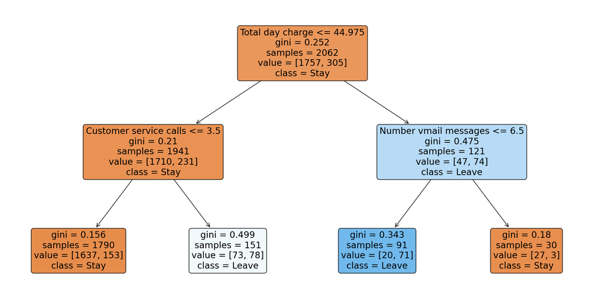

```python
# Visualize the decision tree

plt.figure(figsize=(20,10))
plot_tree(dt_model, filled=True, feature_names=X.columns, class_names=['Stay', 'Leave'], rounded=True)
plt.show()
```

#### c. List the top 5 most important features in order.

```python
feature_importances = pd.DataFrame(dt_model.feature_importances_,
                                   index = X_train.columns,
                                   columns=['importance']).sort_values('importance', ascending=False)

print(feature_importances.head(5))
```

```
                        importance
Total day charge          0.432110
Customer service calls    0.404648
Number vmail messages     0.163242
Total night minutes       0.000000
Total intl charge         0.000000
```

### Task 2: Ensemble Method Implementation (30%)

The goal of this task is to implement a **bagging and a boosting model** . Evaluate their performance on your dataset, providing insights into the differences in their error metrics, and discuss why one might outperform the other in this context.

```python
# Suggested steps:
# 1) Split the data into training and testing sets, ensuring to respect the time series nature if applicable.
# 2) Implement a Bagging Regressor and a Gradient Boosting Regressor.
# 3) Evaluate both models using appropriate metrics for your problem.
# 4) Provide a comparative analysis of their performances.
```

The **AAPL, V, and GOOG datasets** consists of stock quotes companies, where the "Adj Close" price serves as the target variable, reflecting the adjusted closing price of Apple's stock over a specific period.

```python
from sklearn.model_selection import train_test_split
from sklearn.model_selection import TimeSeriesSplit
from sklearn.ensemble import BaggingRegressor, GradientBoostingRegressor
from sklearn.metrics import mean_squared_error, mean_absolute_error, r2_score
```

Below are several first steps of data processing. Make sure that you understand and follow those steps.

```python
from google.colab import files
import pandas as pd
import os

uploaded = files.upload()

file_names = list(uploaded.keys())

def load_and_transform(file_name):
    try:
        df = pd.read_csv(file_name, encoding='utf-8')
    except UnicodeDecodeError:
        df = pd.read_csv(file_name, encoding='ISO-8859-1')

    df['Dt'] = pd.to_datetime(df['Dt'])
    df.set_index('Dt', inplace=True)
    return df

dataframes = {name.split('.')[0]: load_and_transform(name) for name in file_names}

first_df_name = list(dataframes.keys())[0]
df = dataframes[first_df_name]

for df_name in dataframes.keys():
    if df_name != first_df_name:
        df = df.join(dataframes[df_name], how='left', lsuffix=f'_{first_df_name}', rsuffix=f'_{df_name}')

print(df.head())
```

```
Saving AAPL.csv to AAPL.csv
Saving GOOG.csv to GOOG.csv
Saving V.csv to V.csv
            Adj Close_AAPL  Close_AAPL  Div_AAPL  Factor_AAPL  High_AAPL  \
Dt
2017-01-03        110.9539      116.15       0.0          1.0    116.330
2017-01-04        110.8297      116.02       0.0          1.0    116.510
2017-01-05        111.3933      116.61       0.0          1.0    116.864
2017-01-06        112.6351      117.91       0.0          1.0    118.160
2017-01-09        113.6668      118.99       0.0          1.0    119.430

            Low_AAPL  Open_AAPL  Volume_AAPL  Adj Close_GOOG  Close_GOOG  ...  \
Dt                                                                        ...
2017-01-03    114.76   115.8000   28781900.0          786.14      786.14  ...
2017-01-04    115.75   115.8500   21118100.0          786.90      786.90  ...
2017-01-05    115.81   115.9200   22193600.0          794.02      794.02  ...
2017-01-06    116.47   116.7789   31751900.0          806.15      806.15  ...
2017-01-09    117.94   117.9500   33561900.0          806.65      806.65  ...

            Open_GOOG  Volume_GOOG  Adj Close  Close  Div  Factor   High  \
Dt
2017-01-03     778.81    1657300.0    78.0492  79.50  0.0     1.0  79.91
2017-01-04     788.36    1073000.0    78.6874  80.15  0.0     1.0  80.26
2017-01-05     786.08    1335200.0    79.6102  81.09  0.0     1.0  81.53
2017-01-06     795.26    1640200.0    80.7098  82.21  0.0     1.0  82.49
2017-01-09     806.40    1274600.0    80.2582  81.75  0.0     1.0  82.45

              Low   Open      Volume
Dt
2017-01-03  78.49  78.76  13785200.0
2017-01-04  79.36  79.44   8033100.0
2017-01-05  80.22  80.34   7805100.0
2017-01-06  80.94  81.30   8898300.0
2017-01-09  81.65  82.28   7305300.0

[5 rows x 24 columns]
```

```python
# Assuming 'df' is your DataFrame and 'Adj Close_AAPL' is the target variable
X = df.drop('Adj Close_AAPL', axis=1)
y = df['Adj Close_AAPL']

# fill NA
X = X.fillna(0)

# Data Splitting, considering its temporal nature
tscv = TimeSeriesSplit(n_splits=5)
for train_index, test_index in tscv.split(X):
    X_train, X_test = X.iloc[train_index], X.iloc[test_index]
    y_train, y_test = y.iloc[train_index], y.iloc[test_index]
```

#### a. Train and test Bagging Model.

```python
from sklearn.ensemble import BaggingRegressor
from sklearn.metrics import mean_squared_error
```

```python
bagging_model = BaggingRegressor(n_estimators=10, random_state=999)

bagging_model.fit(X_train, y_train)

y_pred_train = bagging_model.predict(X_train)
y_pred_test = bagging_model.predict(X_test)

mse_train = mean_squared_error(y_train, y_pred_train)
mse_test = mean_squared_error(y_test, y_pred_test)

print(f"Bagging Model MSE on training data: {mse_train}")
print(f"Bagging Model MSE on test data: {mse_test}")
```

```
Bagging Model MSE on training data: 0.1307963252250416
Bagging Model MSE on test data: 32.70730464065088
```

#### b. Train and test Boosting Model.

```python
from sklearn.ensemble import GradientBoostingRegressor
```

```python
gbr_model = GradientBoostingRegressor(n_estimators=100, learning_rate=0.1, max_depth=3, random_state=999)

gbr_model.fit(X_train, y_train)

y_pred_train_gbr = gbr_model.predict(X_train)
y_pred_test_gbr = gbr_model.predict(X_test)

mse_train_gbr = mean_squared_error(y_train, y_pred_train_gbr)
mse_test_gbr = mean_squared_error(y_test, y_pred_test_gbr)

print(f"Gradient Boosting Model MSE on training data: {mse_train_gbr}")
print(f"Gradient Boosting Model MSE on test data: {mse_test_gbr}")
```

```
Gradient Boosting Model MSE on training data: 0.08297266501242272
Gradient Boosting Model MSE on test data: 26.940148394824966
```

#### c. Evaluate the model and report (use Mean squared error; Mean absolute error; and R2).

```python
# Model Evaluation using more metrics

# your code here:
mse_bagging = mean_squared_error(y_test, y_pred_test)
mae_bagging = mean_absolute_error(y_test, y_pred_test)
r2_bagging = r2_score(y_test, y_pred_test)

# Boosting 模型评估
mse_boosting = mean_squared_error(y_test, y_pred_test_gbr)
mae_boosting = mean_absolute_error(y_test, y_pred_test_gbr)
r2_boosting = r2_score(y_test, y_pred_test_gbr)


# Printing out the performance metrics with explanations

print("Bagging Model Performance:")
print(f"Mean Squared Error: {mse_bagging}")
print(f"Mean Absolute Error: {mae_bagging}")
print(f"R^2 Score: {r2_bagging}\n")

print("Boosting Model Performance:")
print(f"Mean Squared Error: {mse_boosting}")
print(f"Mean Absolute Error: {mae_boosting}")
print(f"R^2 Score: {r2_boosting}")
```

```
Bagging Model Performance:
Mean Squared Error: 32.70730464065088
Mean Absolute Error: 3.4290869491525444
R^2 Score: 0.8945213166420198

Boosting Model Performance:
Mean Squared Error: 26.940148394824966
Mean Absolute Error: 3.093936974292567
R^2 Score: 0.913119976917236
```

Based on the provided metrics, the Boosting Model outperforms the Bagging Model on the given dataset. Specifically, the Boosting Model exhibits a lower Mean Squared Error (MSE) of 26.940148394824966 compared to the Bagging Model's MSE of 32.70730464065088, indicating better accuracy in predictions. Similarly, the Mean Absolute Error (MAE) is lower for the Boosting Model (3.093936974292567) than for the Bagging Model (3.4290869491525444), suggesting that predictions from the Boosting Model are closer to the actual values. Additionally, the Boosting Model achieves a higher R^2 Score of 0.913119976917236 compared to the Bagging Model's 0.8945213166420198, demonstrating a stronger correlation and a better fit to the data. These results suggest that the Boosting Model may be more effective for this particular dataset, likely due to its ability to sequentially correct errors from previous predictors and focus on difficult cases, thereby providing more accurate predictions.

#### d. Hyperparameter Tuning and Model Optimization.

```python
# Possible steps:
# 1) Choose an ensemble model for hyperparameter tuning (one with the best performance in a previous step).
# 2) Define a parameter grid to explore.
# 3) Use GridSearchCV to find the optimal parameters.
# 4) Retrain the model using the best parameters and evaluate its performance.
```

```python
from sklearn.model_selection import GridSearchCV
from sklearn.ensemble import GradientBoostingRegressor
```

```python
# 1. Choose the model you wish to tune

model_to_tune = GradientBoostingRegressor(random_state=999)


# 2. Define a comprehensive grid of parameters to search

param_grid = {
    'n_estimators': [100, 200, 300],
    'learning_rate': [0.05, 0.1, 0.2],
    'max_depth': [3, 4, 5],
    'min_samples_split': [2, 3, 4]
}

# 3. Perform grid search and identify the best parameters

grid_search = GridSearchCV(estimator=model_to_tune, param_grid=param_grid, cv=5, scoring='neg_mean_squared_error', n_jobs=-1)
grid_search.fit(X_train, y_train)

# 4. Get the best parameters from the grid search

best_params = grid_search.best_params_
print("Best parameters found: ", best_params)

# 5. Retrain the model with the best parameters and evaluate its performance

best_model = GradientBoostingRegressor(**best_params, random_state=999)
best_model.fit(X_train, y_train)

y_pred_train_best = best_model.predict(X_train)
y_pred_test_best = best_model.predict(X_test)

mse_best = mean_squared_error(y_test, y_pred_test_best)
mae_best = mean_absolute_error(y_test, y_pred_test_best)
r2_best = r2_score(y_test, y_pred_test_best)

# 6. Output the performance metrics

print(f"Boosting Model with Best Parameters MSE: {mse_best}")
print(f"Boosting Model with Best Parameters MAE: {mae_best}")
print(f"Boosting Model with Best Parameters R^2 Score: {r2_best}")
```

```
Best parameters found:  {'learning_rate': 0.1, 'max_depth': 5, 'min_samples_split': 2, 'n_estimators': 300}
Boosting Model with Best Parameters MSE: 26.86891987417669
Boosting Model with Best Parameters MAE: 3.121516329369239
Boosting Model with Best Parameters R^2 Score: 0.9133496837260991
```

#### e. Conceptual Questions

- Describe the trade-offs between bias and variance when using ensemble methods.
- How does increasing the diversity of models in an ensemble affect its performance?
- Discuss the implications of temporal dependencies in time series data on the choice and performance of ensemble methods.

1.Ensemble methods, such as bagging and boosting, aim to reduce the trade-off between bias and variance, two fundamental aspects that affect model performance. Bias is the error due to overly simplistic assumptions in the learning algorithm, leading to underfitting. Variance is the error due to too much complexity in the learning algorithm, leading to overfitting. Ensemble methods improve model predictions by combining the strengths of multiple models, potentially reducing variance with techniques like bagging, which averages multiple predictions to smooth out results. Boosting, on the other hand, focuses on sequentially improving the model by specifically addressing misclassified instances, thus reducing bias. However, it's a delicate balance as boosting might increase variance by overfitting to the training data if not carefully implemented.

2.Diversifying the models in an ensemble can significantly enhance its overall performance. The key idea is that different models may capture different aspects of the data, and when combined, these diverse perspectives can offer a more comprehensive understanding, leading to better predictions. For instance, some models might perform well on certain data subsets or feature combinations that others miss. By aggregating these diverse models, ensemble methods can achieve higher accuracy and robustness. However, it's essential to maintain a balance, as too much diversity with poorly performing or irrelevant models can dilute the ensemble's effectiveness.

3.Temporal dependencies present a unique challenge for ensemble methods in time series analysis. These dependencies mean that the order of data points is crucial, as the value at a given time may depend on previous values. Standard ensemble methods that assume independence between data points may not perform well on such data without modifications. It's essential to incorporate models capable of understanding and leveraging these temporal relationships, such as ARIMA or LSTM networks, into the ensemble. Additionally, the method of data splitting for training and validation must respect the time series nature, ensuring that the model is validated on future data points relative to those it was trained on. This careful handling of temporal dependencies is crucial for the successful application of ensemble methods to time series data.

## Part B - Support Vector Machines (40%)

```python
from sklearn.datasets import load_iris
from sklearn.model_selection import train_test_split
from sklearn.svm import SVC
from sklearn.metrics import classification_report, accuracy_score
import matplotlib.pyplot as plt
import seaborn as sns
from sklearn import datasets
from sklearn.preprocessing import StandardScaler
import numpy as np
import pandas as pd
```

### Task 1: SVM Decision Boundaries and C Parameter Investigation (20%)

**The Iris dataset** is a classic in the field of machine learning and statistics, introduced by the British statistician and biologist Ronald Fisher in 1936. The dataset consists of 150 samples from three species of Iris flowers: Iris setosa, Iris versicolor, and Iris virginica. Each sample is described by four features: the length and the width of the sepals and petals, in centimeters. See [wikipedia](https://en.wikipedia.org/wiki/Iris_flower_data_set).

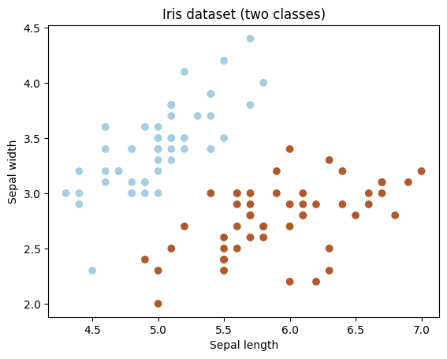

```python
# Load the Iris dataset
iris = datasets.load_iris()
X = iris.data[:, :2]  # we only take the first two features for visualization
y = iris.target

# In the first task, we will consider only 2 classes for binary classification
X = X[y != 2]
y = y[y != 2]

# Visualize the data
plt.scatter(X[:, 0], X[:, 1], c=y, cmap=plt.cm.Paired)
plt.xlabel('Sepal length')
plt.ylabel('Sepal width')
plt.title('Iris dataset (two classes)')
plt.show()
```

#### a. Consider the dataset above. Based on the visual inspection of the plot provided, how would you train an SVM model for this dataset? Explain your choice of kernel and parameters.

For the given Iris dataset, which only considers two features for visualization (sepal length and width) and is limited to two classes, a linear kernel would likely be a good starting point for training an SVM model. This is based on the visual inspection of the plot, where the two classes seem to be linearly separable or close to it.

**Assuming you chose to train a linear SVM with C=100000; answer the following five questions:**

#### b. Report the separating hyperplane.

```python
clf = SVC(kernel='linear', C=100000)
clf.fit(X, y)

w = clf.coef_[0]

b = clf.intercept_[0]

print("The separating hyperplane is given by the equation: {:.2f}*x1 + {:.2f}*x2 + {:.2f} = 0".format(w[0], w[1], b))
```

```
The separating hyperplane is given by the equation: 6.32*x1 + -5.26*x2 + -17.32 = 0
```

#### c. List the support vectors.

```python
support_vectors = clf.support_vectors_

print("The support vectors are:")
print(support_vectors)
```

```
The support vectors are:
[[5.5 3.5]
 [4.5 2.3]
 [4.9 2.4]
 [5.4 3. ]]
```

#### d. Calculate the upper and lower hyperplanes (lines) of the margin

```python
w1, w2, b = 6.32, -5.26, -17.32

# Calculate the slope and intercept for the decision boundary
slope = -w1 / w2
intercept = -b / w2

# Calculate the margin (distance from the hyperplane to the support vectors)
intercept_offset = margin * (w2 / np.sqrt(w1**2 + w2**2))

# Upper and lower hyperplanes
upper_intercept = intercept + intercept_offset
lower_intercept = intercept - intercept_offset

upper_hyperplane = f"x2 = {slope} * x1 + {upper_intercept}"
lower_hyperplane = f"x2 = {slope} * x1 + {lower_intercept}"

upper_hyperplane, lower_hyperplane
```

```
('x2 = 1.2015209125475286 * x1 + -3.448373949676714',
 'x2 = 1.2015209125475286 * x1 + -3.137177381121766')
```

#### e. Compute the width of the margin

```python
w1, w2 = 6.32, -5.26

norm_w = np.sqrt(w1**2 + w2**2)

margin_width = 2 / norm_w

margin_width
```

```
0.24323413767989016
```

#### f. Using the provided SVM model with a high value of C (e.g., C=100000), plot the decision boundaries and margins. Then, adjust the SVM model by setting a very small value for the constant C (e.g., C=0.01). How do you expect this change to affect the margin width? Plot the new decision boundaries and margins and compare them to the previous plot to validate your expectations. Interpret the results

```python
# Suggested steps:
# 1) Train a linear SVM with a large C value (optional if you already did)
# 2) Plot the decision boundaries and margins
# 3) Now train another linear SVM with a small C value
# 4) Plot the new decision boundaries and margins
```

```python
from sklearn import svm
```

```python
# Train a linear SVM with a large C value (optional since we already did)

clf_large_C = svm.SVC(kernel='linear', C=100000)
clf_large_C.fit(X, y)
```

```
SVC(C=100000, kernel='linear')
```

```python
def plot_decision_boundary(clf, X, y, title):
    h = .02  # step size in the mesh
    x_min, x_max = X[:, 0].min() - 1, X[:, 0].max() + 1
    y_min, y_max = X[:, 1].min() - 1, X[:, 1].max() + 1
    xx, yy = np.meshgrid(np.arange(x_min, x_max, h), np.arange(y_min, y_max, h))
    Z = clf.predict(np.c_[xx.ravel(), yy.ravel()])
    Z = Z.reshape(xx.shape)
    plt.contourf(xx, yy, Z, alpha=0.8)
    plt.scatter(X[:, 0], X[:, 1], c=y, edgecolors='k')
    plt.title(title)
```

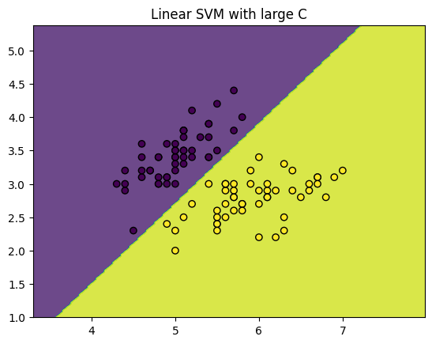

```python
plot_decision_boundary(clf_large_C, X, y, "Linear SVM with large C")
```

```python
clf_small_C = svm.SVC(kernel='linear', C=0.01)
clf_small_C.fit(X, y)
```

```
SVC(C=0.01, kernel='linear')
```

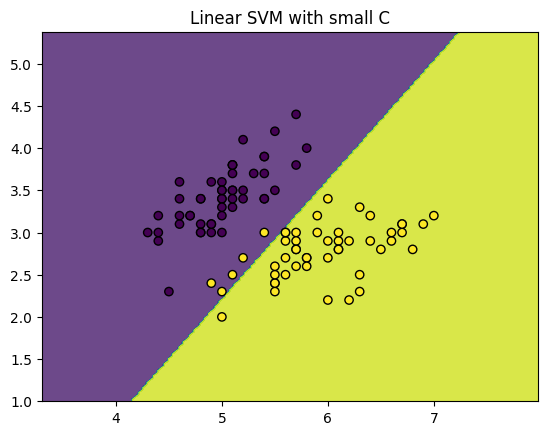

```python
plot_decision_boundary(clf_small_C, X, y, "Linear SVM with small C")
```

### Task 2: Training using SVM (20%)

[figure not shown]

```python
# Load Iris dataset
iris = load_iris(as_frame=True)
df = iris.frame
X = df[['sepal length (cm)','petal width (cm)']].values  # Select the first two features for visualization purposes
y = df.target

# Visualize the data
plt.scatter(X[:, 0], X[:, 1], c=y, cmap=plt.cm.Paired)
plt.xlabel('Sepal length')
plt.ylabel('Sepal width')
plt.title('Iris dataset (all classes)')
plt.show()
```

#### a. Train a linear SVM and a non-linear SVM with RBF kernel using the training set. Use the default arguments, make predictions and calculate accuracy on test set.

```python
# Split the dataset into training and test sets
X_train, X_test, y_train, y_test = train_test_split(X, y, test_size=0.33, random_state=1)
```

```python
# Standardize the data

scaler = StandardScaler()
X_train = scaler.fit_transform(X_train)
X_test = scaler.transform(X_test)
```

```python
# Train a linear SVM

linear_svc = SVC(kernel='linear')
linear_svc.fit(X_train, y_train)
```

```
SVC(kernel='linear')
```

```python
# Train a non-linear SVM with RBF kernel

rbf_svc = SVC(kernel='rbf')
rbf_svc.fit(X_train, y_train)
```

```
SVC()
```

```python
# Make predictions and calculate accuracy on test out-of-sample set

y_pred_linear = linear_svc.predict(X_test)
y_pred_rbf = rbf_svc.predict(X_test)

print("Accuracy of linear SVM:", accuracy_score(y_test, y_pred_linear))
print("Accuracy of non-linear SVM (RBF kernel):", accuracy_score(y_test, y_pred_rbf))
```

```
Accuracy of linear SVM: 0.94
Accuracy of non-linear SVM (RBF kernel): 0.96
```

```python
# Plot decision boundaries (example code below)

def plot_decision_boundary(clf, X, y, title):
    h = .02  # step size in the mesh
    x_min, x_max = X[:, 0].min() - 1, X[:, 0].max() + 1
    y_min, y_max = X[:, 1].min() - 1, X[:, 1].max() + 1
    xx, yy = np.meshgrid(np.arange(x_min, x_max, h), np.arange(y_min, y_max, h))
    Z = clf.predict(np.c_[xx.ravel(), yy.ravel()])
    Z = Z.reshape(xx.shape)
    plt.contourf(xx, yy, Z, alpha=0.8)
    plt.scatter(X[:, 0], X[:, 1], c=y, edgecolors='k')
    plt.title(title)
```

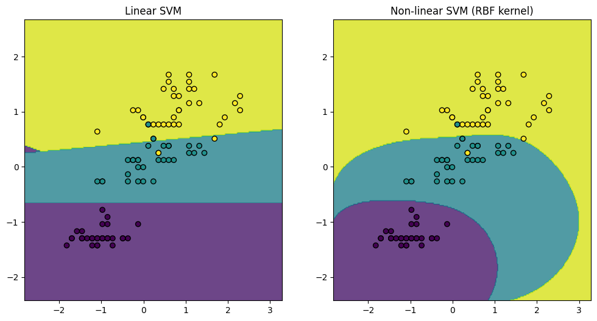

```python
# Plot decision boundaries (example code below)
plt.figure(figsize=(12, 6))
plt.subplot(1, 2, 1)
plot_decision_boundary(linear_svc, X_train, y_train, "Linear SVM")
plt.subplot(1, 2, 2)
plot_decision_boundary(rbf_svc, X_train, y_train, "Non-linear SVM (RBF kernel)")
plt.show()
```

#### b. Train a polynomial SVM using the training set. Use the default arguments, and report both in-sample (training set) and out-of-sample (test set) classification accuracy.

```python
from sklearn.model_selection import train_test_split
```

```python
# Generate training (X_train, Y_train) and testing (X_test, Y_test) datasets for out of sample test

X_train, X_test, Y_train, Y_test = train_test_split(X, y, test_size=0.33, random_state=1)
```

```python
# Train your model.

scaler = StandardScaler()
X_train_scaled = scaler.fit_transform(X_train)
X_test_scaled = scaler.transform(X_test)

poly_svc = SVC(kernel='poly')
poly_svc.fit(X_train_scaled, Y_train)


# Report IS and OS results.

Y_train_pred = poly_svc.predict(X_train_scaled)
train_accuracy = accuracy_score(Y_train, Y_train_pred)
print("In-sample classification accuracy: {:.2f}%".format(train_accuracy * 100))

Y_test_pred = poly_svc.predict(X_test_scaled)
test_accuracy = accuracy_score(Y_test, Y_test_pred)
print("Out-of-sample classification accuracy: {:.2f}%".format(test_accuracy * 100))
```

```
In-sample classification accuracy: 85.00%
Out-of-sample classification accuracy: 96.00%
```

#### c. Try polynomials of degree 1,2,3,4,5. For each degree, consider a variety of regularization constants from the range C=[math.exp(i) for i in np.linspace(-10,2*degree,200)] in order to evaluate the classifier performance over the validation set defined below. Plot the graph of "Accuracy vs log(C)" for each degree.

```python
# Next we generate validation data (X_vali, Y_vali) from the training dataset.
# Denote the remaining training data by (X_train_1, Y_train_1).

X_train_1,X_vali,Y_train_1,Y_vali = train_test_split(X_train, y_train, test_size=0.33, random_state=1)
```

```python
import math
```

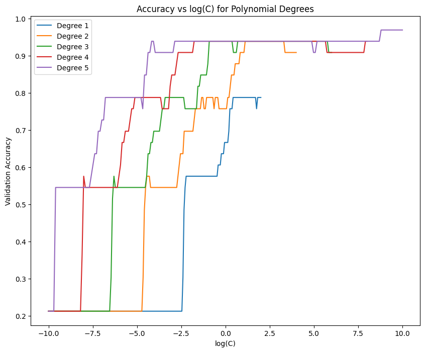

```python
plt.figure(figsize=(10, 8))

for degree in range(1, 6):
    accuracies = []
    C_values = [math.exp(i) for i in np.linspace(-10, 2*degree, 200)]
    log_C_values = np.linspace(-10, 2*degree, 200)

    for C in C_values:
        clf = SVC(kernel='poly', degree=degree, C=C)
        clf.fit(X_train_1, Y_train_1)
        Y_vali_pred = clf.predict(X_vali)
        accuracies.append(accuracy_score(Y_vali, Y_vali_pred))

    plt.plot(log_C_values, accuracies, label=f'Degree {degree}')

plt.xlabel('log(C)')
plt.ylabel('Validation Accuracy')
plt.title('Accuracy vs log(C) for Polynomial Degrees')
plt.legend()
plt.show()
```

#### d. Choose the optimal degree and the optimal regularization constant C based on these graphs. Use the optimal degree and C to compute and report the final out-of-sample accuracy of the best classification model selected.

```python
optimal_degree = 5
optimal_C = np.exp(-10)

poly_svc_optimal = SVC(kernel='poly', degree=optimal_degree, C=optimal_C)
poly_svc_optimal.fit(X_train_scaled, y_train)
```

```
SVC(C=4.5399929762484854e-05, degree=5, kernel='poly')
```

```python
#Report out-of-sample result

y_test_pred = poly_svc_optimal.predict(X_test_scaled)

OS_accuracy = accuracy_score(y_test, y_test_pred)
print(f"Out-of-sample accuracy: {OS_accuracy}")
```

```
Out-of-sample accuracy: 0.28
```

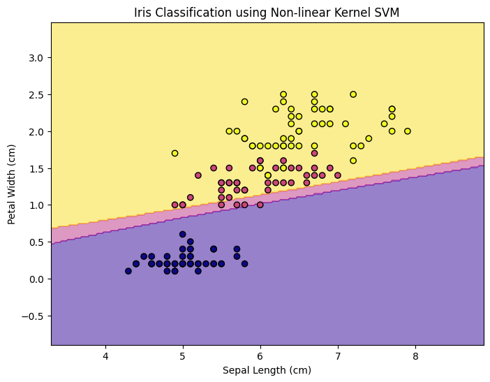

```python
# Plot decision boundary for polynomial SVM using the function (example code below)

x_min, x_max = X[:, 0].min() - 1, X[:, 0].max() + 1
y_min, y_max = X[:, 1].min() - 1, X[:, 1].max() + 1
xx, yy = np.meshgrid(np.arange(x_min, x_max, 0.02),
                     np.arange(y_min, y_max, 0.02))
Z = poly_svc.predict(np.c_[xx.ravel(), yy.ravel()])
Z = Z.reshape(xx.shape)

plt.figure(figsize=(8, 6))
plt.contourf(xx, yy, Z, alpha=0.5, cmap='plasma')
plt.scatter(X[:, 0], X[:, 1], c=y, edgecolors='k', cmap='plasma')
plt.xlabel('Sepal Length (cm)')
plt.ylabel('Petal Width (cm)')
plt.title('Iris Classification using Non-linear Kernel SVM')
plt.show()
```

## Part C - Hierarchical and K-Means Clustering (30%)

For hierarchical and K-Means clustering, use the **Mall Customer Segmentation Data** from Kaggle. For leader clustering, simulate streaming data or use a large dataset divided into chunks to mimic streaming data, such as transaction data or sensor data streams.

```python
import pandas as pd
df = pd.read_csv('Mall_Customers.csv')
df
```

|  | CustomerID | Gender | Age | Annual Income (k$) | Spending Score (1-100) |
| --- | --- | --- | --- | --- | --- |
| 0 | 1 | Male | 19 | 15 | 39 |
| 1 | 2 | Male | 21 | 15 | 81 |
| 2 | 3 | Female | 20 | 16 | 6 |
| 3 | 4 | Female | 23 | 16 | 77 |
| 4 | 5 | Female | 31 | 17 | 40 |
| ... | ... | ... | ... | ... | ... |
| 195 | 196 | Female | 35 | 120 | 79 |
| 196 | 197 | Female | 45 | 126 | 28 |
| 197 | 198 | Male | 32 | 126 | 74 |
| 198 | 199 | Male | 32 | 137 | 18 |
| 199 | 200 | Male | 30 | 137 | 83 |

200 rows × 5 columns

```python
# Start from selecting relevant features for clustering:
# We will be working with two features: 'Annual Income (k$)' and 'Spending Score (1-100)'

X = df[['Annual Income (k$)', 'Spending Score (1-100)']].values

scaler = StandardScaler()
X_scaled = scaler.fit_transform(X)
```

```python
from sklearn.cluster import KMeans
import matplotlib.pyplot as plt
```

### Task 1: Implement K-Means algorithm (10%)

```python
# Implement K-Means

kmeans = KMeans(n_clusters=5, random_state=42)
kmeans.fit(X_scaled)
```

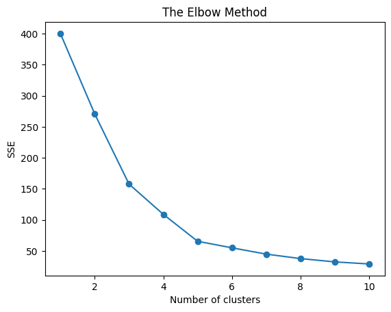

```python
# Check the best number of cluster with any method you like (simple Elbow method is good):

sse = []
for k in range(1, 11):
    kmeans = KMeans(n_clusters=k, random_state=42)
    kmeans.fit(X_scaled)
    sse.append(kmeans.inertia_)

plt.plot(range(1, 11), sse, marker='o')
plt.title('The Elbow Method')
plt.xlabel('Number of clusters')
plt.ylabel('SSE')
plt.show()
```

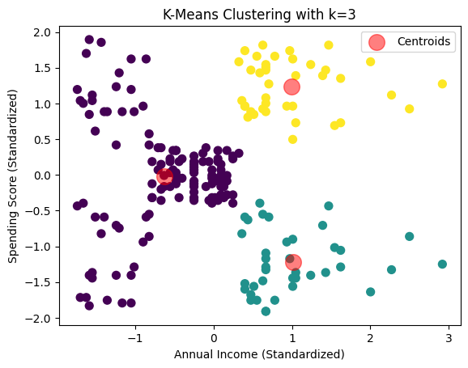

```python
# Plotting clusters

kmeans = KMeans(n_clusters=3, random_state=42)
kmeans.fit(X_scaled)

labels = kmeans.labels_

centers = kmeans.cluster_centers_

plt.scatter(X_scaled[:, 0], X_scaled[:, 1], c=labels, cmap='viridis', s=50)
plt.scatter(centers[:, 0], centers[:, 1], c='red', s=200, alpha=0.5, label='Centroids')
plt.title('K-Means Clustering with k=3')
plt.xlabel('Annual Income (Standardized)')
plt.ylabel('Spending Score (Standardized)')
plt.legend()
plt.show()
```

### Task 2: Implement a Hierarchical Clustering algorithm (10%)

```python
from sklearn.cluster import AgglomerativeClustering
import matplotlib.pyplot as plt
import numpy as np
```

```python
# For Hierarchical Clustering, you can perform Agglomerative Clustering
clustering = AgglomerativeClustering(n_clusters=3)
clustering.fit(X_scaled)

labels = clustering.labels_
```

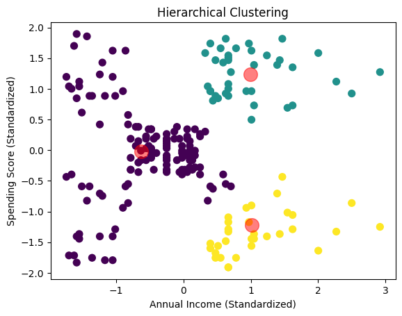

```python
# Plot the clusters (for 2D data)

plt.scatter(X_scaled[:, 0], X_scaled[:, 1], c=labels, cmap='viridis', s=50)
plt.scatter(centers[:, 0], centers[:, 1], c='red', s=200, alpha=0.5, label='Centroids')
plt.title('Hierarchical Clustering')
plt.xlabel('Annual Income (Standardized)')
plt.ylabel('Spending Score (Standardized)')
plt.show()
```

### Task 3: Evaluate and report clustering quality using silhouette scores (10%).

Silhouette score is a tool for assessing the appropriateness of clustering results by providing a quantitative measure of how well-defined and distinct the clusters are. The Silhouette Score quantifies how well a data point fits into its assigned cluster and how distinct it is from other clusters.

```python
from sklearn.metrics import silhouette_score

silhouette_avg_kmeans = silhouette_score(X_scaled, kmeans.labels_)
print(f"K-Means Silhouette Score: {silhouette_avg_kmeans}")


# For Hierarchical Model

silhouette_avg_hierarchical = silhouette_score(X_scaled, clustering.labels_)
print(f"Hierarchical Clustering Silhouette Score: {silhouette_avg_hierarchical}")
```

```
K-Means Silhouette Score: 0.46658474419000145
Hierarchical Clustering Silhouette Score: 0.4610481446570447
```

#### Discuss which method works the best for this dataset. Elaborate if those methods are good fit for this data.

The silhouette scores for both K-Means and Hierarchical Clustering are relatively close, with K-Means scoring slightly higher at 0.4666 compared to 0.4610 for Hierarchical Clustering. This suggests that both clustering methods have performed reasonably well in separating the clusters with a fair level of distinction between them.

Given the scores, K-Means may be considered the better method for this dataset by a small margin. However, it's important to note that both scores are not particularly high, which implies that while there is some cluster structure, the clusters are not very dense nor well separated. This could be an indicator that the chosen features — 'Annual Income' and 'Spending Score' — do capture some patterns in the data, but they may not be the most definitive features for clustering this particular dataset.